# COVID-19 CT Scan Classifier

This notebook trains a model that sorts chest CT slices into three groups:

| Class | Meaning |
| --- | --- |
| `nCT` | Normal CT. The lungs are visible and show no signs of COVID-19 |
| `pCT` | Positive CT. The lungs show changes typical for COVID-19 pneumonia |
| `NiCT` | Non-informative CT. The slice doesn't show enough of the lungs to judge |

It started as a university project about a year ago, trained on a Windows PC with an RTX 2060. This version runs on a MacBook with Apple Silicon and trains on the Mac's GPU through PyTorch's MPS backend.

The approach is transfer learning. I take MobileNetV3-Large, which is already trained on millions of everyday photos (ImageNet), replace its last layers with a small classifier that has three outputs, and then fine-tune the whole network on the CT images.

**Dataset:** [CT Scans for COVID-19 Classification](https://www.kaggle.com/datasets/azaemon/preprocessed-ct-scans-for-covid19) on Kaggle (19,685 slices, CC BY 4.0), built from the iCTCF data of Ning et al. (2020). The download contains the original slices and a preprocessed version where the lungs have been cut out of each slice. This notebook uses the original slices, the same images as my first run.

> This is a learning project, not a medical tool. Don't use it to make decisions about anyone's health.

## Running it yourself

You need Python 3.11, a free Kaggle account and about 4 GB of disk space for the data.

```
python3.11 -m venv .venv
source .venv/bin/activate
pip install -r requirements.txt

# Kaggle API token: kaggle.com > Settings > API > Create New Token, then:
mkdir -p ~/.kaggle && mv ~/Downloads/kaggle.json ~/.kaggle/ && chmod 600 ~/.kaggle/kaggle.json

kaggle datasets download -d azaemon/preprocessed-ct-scans-for-covid19 -p ~/datasets/covid-ct --unzip
```

From the download, copy the `nCT`, `NiCT` and `pCT` folders of the **original** CT scans into a folder called `CT Scans` next to this notebook.

The full training run (25 epochs) took about 40 minutes on a MacBook Pro M5 Pro. Without an Apple GPU it falls back to the CPU, which is a lot slower.

## Imports

```python
%matplotlib inline
%config InlineBackend.figure_format = 'retina'

import random
import time
from pathlib import Path

import numpy as np
import matplotlib.pyplot as plt
from PIL import Image
from IPython.display import display

import torch
from torch import nn, optim
import torch.nn.functional as F
from torch.utils.data import DataLoader, Subset
from torchvision import datasets, transforms, models
```

## Settings

Everything you might want to change lives in this cell: where the images are, the training settings and the device. The training settings are the same as in my original run, so the results can be compared.

`SMOKE_TEST = True` trains for a single epoch. That's handy for checking that everything works before starting the full run.

```python
DATA_ROOT      = Path("CT Scans")   # contains the nCT, NiCT and pCT folders
OUTPUT_DIR     = Path("outputs")
CHECKPOINT_DIR = OUTPUT_DIR / "checkpoints"
CHECKPOINT_DIR.mkdir(parents=True, exist_ok=True)

BATCH_SIZE  = 16
IMG_SHAPE   = 224
EPOCHS      = 25
MODEL_NAME  = "mobilenet_v3_large"
FINE_TUNING = True

SMOKE_TEST = False
if SMOKE_TEST:
    EPOCHS = 1

# Apple GPU if available, otherwise CPU
device = torch.device("mps" if torch.backends.mps.is_available() else "cpu")

# Mixed precision runs on MPS, but in my tests it was slower than plain float32 for this model
USE_AMP = False

# 4 workers load images fast enough to keep the GPU busy. pin_memory only helps on NVIDIA GPUs.
NUM_WORKERS = 4
PIN_MEMORY  = False

print(f"PyTorch {torch.__version__} | device: {device} | epochs: {EPOCHS}")
```

```
PyTorch 2.14.1 | device: mps | epochs: 25
```

## The dataset

The images sit in three folders, one per class: `nCT`, `NiCT` and `pCT`. The next two cells read the class names from the folder names and check that every image is there.

```python
EXPECTED_CLASSES = {"nCT", "NiCT", "pCT"}

classes = sorted(d.name for d in DATA_ROOT.iterdir() if d.is_dir())
assert EXPECTED_CLASSES <= set(classes), f"Expected the folders {sorted(EXPECTED_CLASSES)} in {DATA_ROOT}, found {classes}"

print("Classes:", classes)
```

```
Classes: ['NiCT', 'nCT', 'pCT']
```

```python
EXPECTED_COUNTS = {"nCT": 9979, "NiCT": 5705, "pCT": 4001}
IMAGE_EXTS = {".png", ".jpg", ".jpeg", ".bmp", ".tif", ".tiff"}

def count_images(folder):
    return sum(1 for p in Path(folder).iterdir() if p.suffix.lower() in IMAGE_EXTS)

for c in classes:
    n = count_images(DATA_ROOT / c)
    print(f"{c:5s} {n:6,} images")
    assert n == EXPECTED_COUNTS[c], f"{c}: found {n} images, expected {EXPECTED_COUNTS[c]}"
```

```
NiCT   5,705 images
nCT    9,979 images
pCT    4,001 images
```

## Loading the data

**Split.** Each class is shuffled with a fixed seed (42) and cut into roughly 70% training, 15% validation and 15% test images. The exact numbers per class are hardcoded, so the split is the same every time the notebook runs. No files are copied; the split is just three lists of image indices.

**Transforms.** All images are resized and normalised with the ImageNet statistics, because that's what the pretrained network expects. Training images also get random crops and horizontal flips, so the model sees slightly different versions of each slice in every epoch. Validation and test images always get the same center crop.

```python
# Transforms
data_transforms = {
    'train': transforms.Compose([
        transforms.Resize(256),
        transforms.RandomResizedCrop(IMG_SHAPE),
        transforms.RandomHorizontalFlip(),
        transforms.ToTensor(),
        transforms.Normalize([0.485, 0.456, 0.406],
                             [0.229, 0.224, 0.225]),
    ]),
    'valid': transforms.Compose([
        transforms.Resize(256),
        transforms.CenterCrop(IMG_SHAPE),
        transforms.ToTensor(),
        transforms.Normalize([0.485, 0.456, 0.406],
                             [0.229, 0.224, 0.225]),
    ]),
}

base = datasets.ImageFolder(DATA_ROOT)
classes = base.classes
print("Classes:", classes)

target = {
    "pCT":  {"train": 2800, "valid": 600,  "test": 601},
    "NiCT": {"train": 3993, "valid": 855,  "test": 857},
    "nCT":  {"train": 6985, "valid": 1496, "test": 1498},
}

rng = random.Random(42)
idx_by_class = {c: [] for c in classes}
for i, (_, y) in enumerate(base.samples):
    idx_by_class[classes[y]].append(i)

train_idx, val_idx, test_idx = [], [], []
for c in classes:
    idxs = idx_by_class[c]
    rng.shuffle(idxs)
    t = target[c]["train"]; v = target[c]["valid"]; s = target[c]["test"]
    need = t + v + s
    if len(idxs) < need:
        raise ValueError(f"{c}: found {len(idxs)} images, need {need}.")
    train_idx += idxs[:t]
    val_idx   += idxs[t:t+v]
    test_idx  += idxs[t+v:t+v+s]

train_ds = Subset(datasets.ImageFolder(DATA_ROOT, transform=data_transforms['train']), train_idx)
val_ds   = Subset(datasets.ImageFolder(DATA_ROOT, transform=data_transforms['valid']), val_idx)
test_ds  = Subset(datasets.ImageFolder(DATA_ROOT, transform=data_transforms['valid']), test_idx)

loader_kwargs = dict(batch_size=BATCH_SIZE, num_workers=NUM_WORKERS, pin_memory=PIN_MEMORY,
                     persistent_workers=NUM_WORKERS > 0)
dataloaders = {
    'trainloader': DataLoader(train_ds, shuffle=True,  **loader_kwargs),
    'validloader': DataLoader(val_ds,   shuffle=False, **loader_kwargs),
    'testloader' : DataLoader(test_ds,  shuffle=False, **loader_kwargs),
}

print(f"Split: {len(train_idx):,} train / {len(val_idx):,} validation / {len(test_idx):,} test")

xb, yb = next(iter(dataloaders['trainloader']))
print("Batch:", xb.shape, yb.shape)
```

```
Classes: ['NiCT', 'nCT', 'pCT']
Split: 13,778 train / 2,951 validation / 2,956 test
```

```
Batch: torch.Size([16, 3, 224, 224]) torch.Size([16])
```

### Class names

PyTorch numbers the classes alphabetically by folder name (`NiCT` = 0, `nCT` = 1, `pCT` = 2). This maps them to readable names for the plots later on.

```python
class_to_name = {
    "nCT":  "Normal CT scan",
    "NiCT": "Non-informative CT (lungs not visible enough to judge)",
    "pCT":  "COVID-19 positive CT scan",
}

class_to_idx = base.class_to_idx
idx_to_class = {v: k for k, v in class_to_idx.items()}
idx_to_name  = {i: class_to_name[idx_to_class[i]] for i in idx_to_class}

print("class_to_idx:", class_to_idx)
print("idx_to_name:", idx_to_name)
```

```
class_to_idx: {'NiCT': 0, 'nCT': 1, 'pCT': 2}
idx_to_name: {0: 'Non-informative CT (lungs not visible enough to judge)', 1: 'Normal CT scan', 2: 'COVID-19 positive CT scan'}
```

## The model

MobileNetV3-Large turns each image into 960 numbers (features). Its original last layers turn those into 1,000 ImageNet classes. I replace them with my own small classifier:

960 features → 1,280 neurons (ReLU + 20% dropout) → 3 classes

The output goes through a log-softmax, which pairs with the `NLLLoss` loss function used below.

```python
class Classifier(nn.Module):
    def __init__(
        self,
        input_size: int,
        output_size: int,
        hidden_layers=(1280,),
        drop_p: float = 0.2,
        use_log_softmax: bool = True
    ):
        super().__init__()

        if isinstance(hidden_layers, int):
            hidden_layers = [hidden_layers]

        layers = []
        prev = input_size

        for h in (hidden_layers or []):
            layers.append(nn.Linear(prev, h))
            layers.append(nn.ReLU(inplace=True))
            layers.append(nn.Dropout(p=drop_p))
            prev = h

        layers.append(nn.Linear(prev, output_size))

        self.net = nn.Sequential(*layers)
        self.use_log_softmax = use_log_softmax

    def forward(self, x):
        x = self.net(x)
        return F.log_softmax(x, dim=1) if self.use_log_softmax else x
```

### Validation function

Runs the model over a dataset without training it and returns the average loss and the accuracy. It's used for the validation set during training and for all three splits at the end.

```python
def validation(model, validloader, criterion, device):
    """Return the average loss and the accuracy of the model on one data split."""
    model.eval()
    loss_sum = 0.0
    correct  = 0
    n        = 0

    with torch.no_grad():
        for inputs, labels in validloader:
            inputs = inputs.to(device, non_blocking=True)
            labels = labels.to(device, non_blocking=True)

            outputs = model(inputs)
            loss    = criterion(outputs, labels)

            bs = labels.size(0)
            loss_sum += loss.item() * bs

            preds = outputs.argmax(dim=1)
            correct += (preds == labels).sum().item()
            n += bs

    avg_loss = loss_sum / n if n else 0.0
    avg_acc  = correct  / n if n else 0.0
    return avg_loss, avg_acc
```

### Training function

The usual PyTorch loop: forward pass, loss, backward pass, optimizer step. Every 50 steps it checks the validation set and prints the progress. After each epoch it prints how long the epoch took and roughly how much time is left.

```python
def format_duration(seconds):
    m, s = divmod(int(round(seconds)), 60)
    h, m = divmod(m, 60)
    return f"{h}h{m:02d}m{s:02d}s" if h else f"{m}m{s:02d}s"

def training(model, criterion, optimizer, device,
             trainloader, validloader,
             epochs: int = 5, print_every: int = 50, use_amp: bool = False):
    """Train the model and return the validation loss/accuracy and duration of every epoch."""
    model.to(device)
    scaler = torch.amp.GradScaler(device.type, enabled=use_amp)

    print(f"Training on {device} (mixed precision: {use_amp})")

    history = {"val_loss": [], "val_acc": [], "epoch_time": []}
    t_start = time.perf_counter()

    for e in range(1, epochs + 1):
        t_epoch = time.perf_counter()
        model.train()
        running_loss = 0.0

        for step, (inputs, labels) in enumerate(trainloader, 1):
            inputs = inputs.to(device, non_blocking=True)
            labels = labels.to(device, non_blocking=True)

            optimizer.zero_grad(set_to_none=True)

            with torch.autocast(device_type=device.type, dtype=torch.float16, enabled=use_amp):
                outputs = model(inputs)
                loss = criterion(outputs, labels)

            scaler.scale(loss).backward()
            scaler.step(optimizer)
            scaler.update()

            running_loss += loss.item()

            if step % print_every == 0:
                val_loss, val_acc = validation(model, validloader, criterion, device)
                avg_train = running_loss / print_every
                print(f"Epoch {e}/{epochs}  Step {step}/{len(trainloader)}  "
                      f"TrainLoss {avg_train:.4f}  ValLoss {val_loss:.4f}  ValAcc {val_acc:.4f}  "
                      f"[{format_duration(time.perf_counter() - t_epoch)}]")
                running_loss = 0.0
                model.train()

        val_loss, val_acc = validation(model, validloader, criterion, device)
        epoch_time = time.perf_counter() - t_epoch
        eta = (time.perf_counter() - t_start) / e * (epochs - e)
        history["val_loss"].append(val_loss)
        history["val_acc"].append(val_acc)
        history["epoch_time"].append(epoch_time)
        print(f"Epoch {e}/{epochs} done  ValLoss {val_loss:.4f}  ValAcc {val_acc:.4f}  "
              f"| took {format_duration(epoch_time)}, about {format_duration(eta)} left")

    print(f"Training finished in {format_duration(time.perf_counter() - t_start)}")
    return history
```

### Building the model

Load MobileNetV3-Large with its pretrained ImageNet weights and swap in the new classifier. With `FINE_TUNING = True` the whole network keeps learning, not just the new layers.

```python
hyper_parameters = {
    'input_size'   : 960,
    'output_size'  : len(classes),
    'hidden_layers': [1280],
    'drop_p'       : 0.2,
    'learn_rate'   : 1e-4,
    'epochs'       : EPOCHS,
    'model'        : MODEL_NAME,
}

classifier = Classifier(
    input_size    = hyper_parameters['input_size'],
    output_size   = hyper_parameters['output_size'],
    hidden_layers = hyper_parameters['hidden_layers'],
    drop_p        = hyper_parameters['drop_p'],
    use_log_softmax = True
)

model = models.mobilenet_v3_large(weights="DEFAULT")

if not FINE_TUNING:
    for p in model.features.parameters():
        p.requires_grad = False

model.classifier = classifier

model = model.to(device)

print(model.classifier)
```

```
Classifier(
  (net): Sequential(
    (0): Linear(in_features=960, out_features=1280, bias=True)
    (1): ReLU(inplace=True)
    (2): Dropout(p=0.2, inplace=False)
    (3): Linear(in_features=1280, out_features=3, bias=True)
  )
)
```

### Loss function and optimizer

`NLLLoss` (negative log-likelihood) matches the log-softmax output of the classifier; together they work the same as the usual cross-entropy loss. The optimizer is AdamW with a small learning rate (0.0001), because the pretrained weights are already good and should only be adjusted gently.

```python
model = model.to(device)

criterion = nn.NLLLoss()

optimizer = optim.AdamW(
    (p for p in model.parameters() if p.requires_grad),
    lr=hyper_parameters['learn_rate'],
    weight_decay=1e-4
)

total_params = sum(p.numel() for p in model.parameters() if p.requires_grad)
print(f"Trainable parameters: {total_params:,} | lr={hyper_parameters['learn_rate']} | device={device}")
```

```
Trainable parameters: 4,205,875 | lr=0.0001 | device=mps
```

## Training

```python
history = training(
    model,
    criterion,
    optimizer,
    device,
    trainloader = dataloaders['trainloader'],
    validloader = dataloaders['validloader'],
    epochs = hyper_parameters['epochs'],
    use_amp = USE_AMP,
)
```

[output not shown]

```
Training on mps (mixed precision: False)
```

```
Training finished in 41m07s
```

## Results

Accuracy and loss on all three splits. The test images were never used during training or for any decision about the model, so the test number is the fairest estimate of how it does on new slices from this dataset.

The training accuracy can come out slightly *lower* than validation and test. That's because the training images are still randomly cropped and flipped here, which makes them harder than the clean center crops used for the other two splits.

```python
train_loss, train_acc = validation(model, dataloaders['trainloader'], criterion, device)
val_loss,   val_acc   = validation(model, dataloaders['validloader'], criterion, device)

print(f"Train: acc = {train_acc:.4f} ({train_acc*100:.2f}%), loss = {train_loss:.4f}")
print(f"Valid: acc = {val_acc:.4f} ({val_acc*100:.2f}%), loss = {val_loss:.4f}")
```

```
Train: acc = 0.9870 (98.70%), loss = 0.0316
Valid: acc = 0.9925 (99.25%), loss = 0.0216
```

```python
test_loss,  test_acc  = validation(model, dataloaders['testloader'],   criterion, device)
print(f"Test : acc = {test_acc:.4f} ({test_acc*100:.2f}%), loss = {test_loss:.4f}")
```

```
Test : acc = 0.9976 (99.76%), loss = 0.0070
```

**How did it go?** On the Mac the model ends up at 98.70% on the training set, 99.25% on validation and 99.76% on the test set. The original run on the RTX 2060 got 98.58%, 99.42% and 99.53%, so the port to Apple Silicon gives practically the same model.

Keep the limitations at the end of the notebook in mind, though. These numbers are very likely too optimistic for scans of new patients.

## Saving the model

The checkpoint stores the weights along with everything needed to rebuild the model later: classifier size, image size and the class order.

```python
checkpoint = {
    "arch": MODEL_NAME,
    "input_size": hyper_parameters["input_size"],
    "output_size": hyper_parameters["output_size"],
    "hidden_layers": hyper_parameters["hidden_layers"],
    "drop_p": hyper_parameters["drop_p"],
    "fine_tuning": FINE_TUNING,
    "img_shape": IMG_SHAPE,
    "class_to_idx": base.class_to_idx,
    "classes": classes,
    "state_dict": model.state_dict(),
}

filepath = CHECKPOINT_DIR / (f"{MODEL_NAME}_smoke.pth" if SMOKE_TEST else f"{MODEL_NAME}.pth")
torch.save(checkpoint, filepath)
print("Saved", filepath)
```

```
Saved outputs/checkpoints/mobilenet_v3_large.pth
```

### Loading it back

To make sure the checkpoint works, the model is rebuilt from the file and used for the predictions below.

```python
def load_checkpoint(filepath, device):
    """Rebuild the trained model from a checkpoint file, ready for predictions."""
    ckpt = torch.load(filepath, map_location=device)
    assert ckpt["arch"] == "mobilenet_v3_large", f"Unexpected architecture: {ckpt['arch']}"

    model = models.mobilenet_v3_large(weights=None)
    model.classifier = Classifier(
        input_size=ckpt["input_size"],
        output_size=ckpt["output_size"],
        hidden_layers=ckpt["hidden_layers"],
        drop_p=ckpt["drop_p"],
    )
    model.load_state_dict(ckpt["state_dict"])
    model.class_to_idx = ckpt["class_to_idx"]
    model.classes = ckpt["classes"]
    return model.to(device).eval()
```

```python
t0 = time.perf_counter()
model = load_checkpoint(filepath, device)
print(f"Loaded {filepath} in {time.perf_counter() - t0:.2f}s")
```

```
Loaded outputs/checkpoints/mobilenet_v3_large.pth in 0.20s
```

## Predicting single images

To classify one image, it has to go through the same steps as the validation images during training: resize, center crop, convert to a tensor and normalise.

```python
def process_image(image_path):
    """Load an image and prepare it for the model. Returns a tensor of shape [1, 3, 224, 224]."""
    im = Image.open(image_path).convert("RGB")

    preprocess = transforms.Compose([
        transforms.Resize(256),
        transforms.CenterCrop(IMG_SHAPE),
        transforms.ToTensor(),
        transforms.Normalize(mean=[0.485, 0.456, 0.406],
                             std=[0.229, 0.224, 0.225]),
    ])
    return preprocess(im).unsqueeze(0)
```

`imshow` turns a tensor back into a picture by undoing the normalisation. It's a quick visual check that the preprocessing doesn't cut off anything important.

```python
def imshow(image, ax=None, title=None, denorm=True):
    """Display a tensor image. Accepts [3,H,W] or [1,3,H,W]."""
    if ax is None:
        fig, ax = plt.subplots()

    if torch.is_tensor(image):
        img = image.detach().cpu()
        if img.dim() == 4:
            img = img[0]
        img = img.permute(1, 2, 0).numpy()
    else:
        img = np.asarray(image)

    if denorm:
        mean = np.array([0.485, 0.456, 0.406])
        std  = np.array([0.229, 0.224, 0.225])
        img = std * img + mean

    img = np.clip(img, 0, 1)
    ax.imshow(img)
    if title is not None:
        ax.set_title(title)
    ax.axis('off')
    return ax
```

```
Test image: pCT/pCT3824.jpg (class pCT)
```

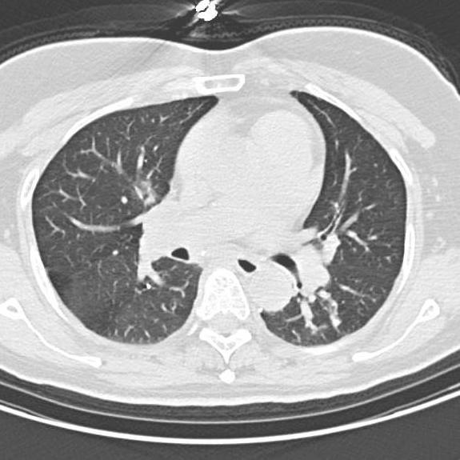

```python
idx = random.choice(test_idx)
img_path, y = base.samples[idx]
print(f"Test image: {Path(img_path).relative_to(DATA_ROOT)} (class {classes[y]})")

display(Image.open(img_path).convert("RGB"))
```

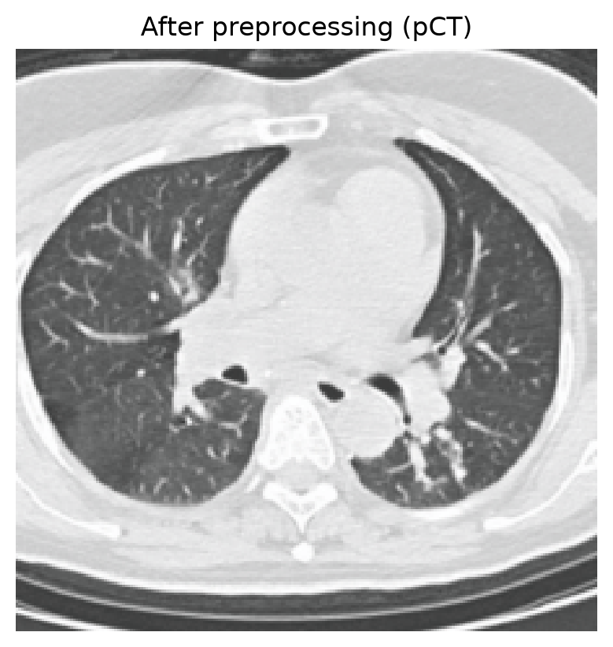

```python
image = process_image(img_path)
imshow(image, title=f"After preprocessing ({classes[y]})");
```

### Prediction

`predict` runs one image through the model and turns the output into probabilities with softmax. `predict_classes_names` swaps the folder names for the readable class names.

```python
def predict(image_path, model, topk=3):
    """Return the top-k probabilities and their class folder names for one image."""
    model.eval()
    x = process_image(image_path).to(device)

    with torch.no_grad():
        probs = torch.softmax(model(x), dim=1)

    topk = min(topk, probs.shape[1])
    prob_vals, idxs = probs.topk(topk, dim=1)

    idx_to_class = {v: k for k, v in model.class_to_idx.items()}
    classes_pred = [idx_to_class[i.item()] for i in idxs[0]]
    return prob_vals[0].cpu().numpy(), classes_pred
```

```python
def predict_classes_names(image_path, model, cat_to_name=None, topk=3):
    """Like predict(), but returns readable class names when a mapping is given."""
    probs, classes_pred = predict(image_path, model, topk=topk)
    if cat_to_name:
        return probs, [cat_to_name.get(c, c) for c in classes_pred]
    return probs, classes_pred
```

`prediction_displaying` shows the image, titled with its true class, above a bar chart of the predicted probabilities.

```python
def prediction_displaying(image_path, probs, classes_names, cat_to_name=None):
    """Plot the image (titled with its true class) above a bar chart of the predicted probabilities."""
    image = Image.open(image_path).convert("RGB")

    fig, (ax1, ax2) = plt.subplots(
        nrows=2, ncols=1, figsize=(7, 9),
        gridspec_kw={"height_ratios": [3, 2]}
    )

    folder_label = Path(image_path).parent.name
    title = cat_to_name.get(folder_label, folder_label) if cat_to_name else folder_label

    ax1.imshow(image)
    ax1.set_title(title)
    ax1.axis("off")

    probs = np.asarray(probs).reshape(-1)
    y_pos = np.arange(len(probs))

    ax2.barh(y_pos, probs, align="center")
    ax2.set_yticks(y_pos)
    ax2.set_yticklabels(classes_names)
    ax2.set_xlim(0, 1)
    ax2.set_xlabel("Probability")
    ax2.set_title("Class Probability")
    ax2.invert_yaxis()

    for i, p in enumerate(probs):
        ax2.text(min(p + 0.02, 0.98), i, f"{p*100:.1f}%", va="center")

    plt.tight_layout()
    return fig, (ax1, ax2)
```

### Trying it on a random test image

Every run of this cell picks a different image from the test set.

```
Test image: NiCT/NiCT3205.jpg
```

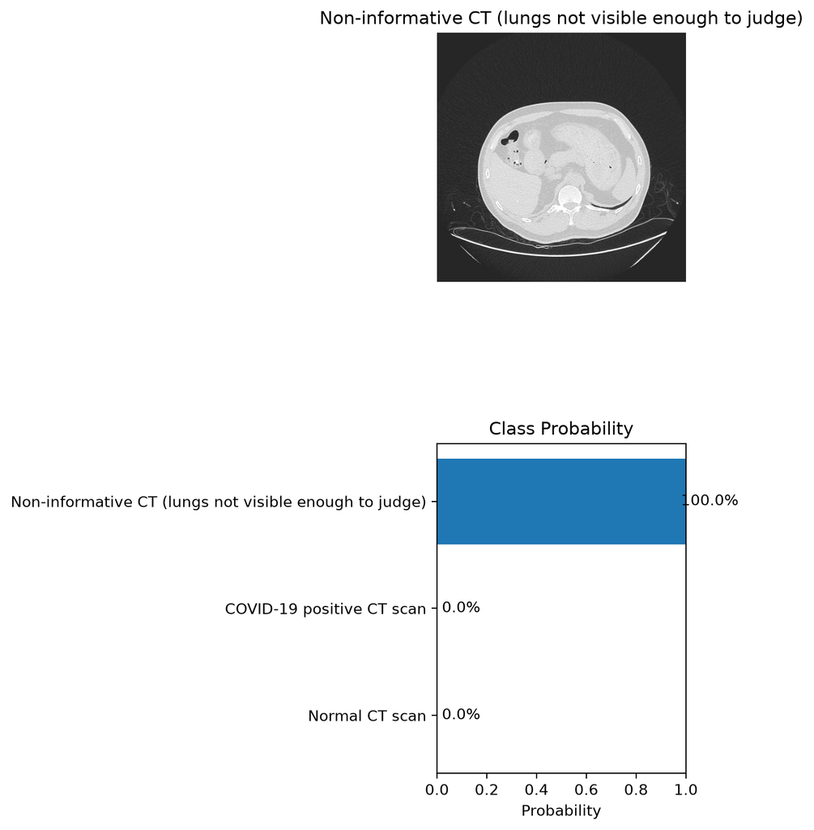

```
Ground truth: Non-informative CT (lungs not visible enough to judge)
100.00%  Non-informative CT (lungs not visible enough to judge)
  0.00%  COVID-19 positive CT scan
  0.00%  Normal CT scan
```

```python
idx = random.choice(test_idx)
image_path, y_true = base.samples[idx]
print("Test image:", Path(image_path).relative_to(DATA_ROOT))

probs, names = predict_classes_names(image_path, model, cat_to_name=class_to_name, topk=len(classes))
prediction_displaying(image_path, probs, names, cat_to_name=class_to_name)
plt.show()

print("Ground truth:", class_to_name[classes[y_true]])
for p, n in zip(probs, names):
    print(f"{p:7.2%}  {n}")
```

## Limitations

- **The split is per image, not per patient.** The dataset has many slices from each patient, and neighbouring slices look very similar. Slices from the same person can end up in both training and test, which makes the test accuracy look better than it would be on completely new patients.
- **One dataset, two hospitals.** All scans come from two hospitals in Wuhan. Scans from other machines or hospitals can look different, and the model has never seen those.
- **Slices, not patients.** The model judges single slices. A real diagnosis looks at the whole scan, symptoms and lab results.